# A Text-As-Data Approach for Open-Ended Manipulation Checks

Jeffrey Ziegler

Political Analysis (2022) · Presented by Ago Echeverri

2026-04-29

## The Problem

- **Online respondents may be inattentive**
- Survey tasks are easy to skim. As many as half of respondents in some studies display low attention (Berinsky et al. 2014).
- Inattentive respondents add noise to treatment effect estimates and can mask or inflate effects.

## The Problem

- **In experimental studies:**
- Inattentiveness can cause manipulations to fail, making treated participants indistinguishable from control participants
- Furthermore, in case of a null, it is not straightforward to know whether the treatment was not absorbed, or if it was absorbed but failed to move the DV

## Solution?

- Using Manipulation Checks
- Use **Substantive MCs** to check if the latent variable was moved
- Use **Factual MCs** to check if the treatment was absorbed

## The Problem (again)

- Pass-fail MCs will always have false positives (Kane & Barabas 2019)
- Example: Dietrich & Winters (2015)
- Do you remember the Samastha HIV/AIDS prevention program that we described earlier?
  1. Yes (b) No

## The Problem (again)

- Do you remember who provided the funding for that program?
  1. Indian national government
  2. Karnataka state government
  3. United States of America government
  4. Not sure / do not remember.

## Solution? (Again)

- Ziegler’s answer: using open-ended responses, and coding them with automated similarity measures
- Like that, we obtain a *continuous* measure of attentiveness with less likelihood of passing “by mistake”

## The Proposal: Open-Ended Response + Similarity

- **Respondent reads the treatment**
- Kane (2020) news selection experiment: 3x1 framing design
- N = 742 · Nationally representative U.S. sample
- Treatment: News headline about Trump
  - *United*: “pleases his conservative supporters”
  - *Disunited*: “upsets his conservative supporters”
  - *Control*: Biographical info
- DV: Select Trump story vs. 3 alternatives (binary)
- MC: Open-ended recall of headline (post-treatment)

## Proposal: Open-Ended Response + Similarity

- **Respondent is asked to paraphrase the treatment**
- Follow-up question: **Please briefly describe what the story option concerning President Trump was about.**
- **Computing similarity with the treatment**
- Both the text response and the treatment headline are transformed into **trigrams**, then they are compared with one another.

## Trigrams (and n-grams)

- A “bag-of-words” approach would be vulnerable to false negatives, because of grammar and spelling mistakes.
- Every word is decomposed into **trigrams**.
- Slide a 3-character window across `"banana"`:

```
[ban]ana   →  ban b[ana]na   →  ana ba[nan]a   →  nan ban[ana]   →  ana
```

- Unique trigram vector: $\{\text{ban},\ \text{ana},\ \text{nan}\}$

## Similarity Metrics: Jaccard

- **Jaccard Similarity**
- Intersection over union of trigram sets.

$$J(A, B) = \frac{|A \cap B|}{|A \cup B|}$$

- Penalizes longer responses: a detailed reply may score lower than a brief but precise one.
- Range: [0, 1] · 1 = perfect overlap

## Similarity Metrics: Cosine

- **Cosine Similarity**
- Angle between trigram frequency vectors.

$$\text{sim}(\mathbf{r}_i, \mathbf{t}) = \frac{\mathbf{r}_i \cdot \mathbf{t}}{\|\mathbf{r}_i\| \, \|\mathbf{t}\|} \in [-1, 1]$$

- Corr. with ‘correct’ answer: r = 0.74
- Corr. with word embeddings: r = 0.87
- Range: [0, 1] · 1 = identical orientation

## Jaccard vs Cosine

| Response | Length | Jaccard | Cosine |
| --- | --- | --- | --- |
| “Trump angers conservatives” | short | ≈ 0.42 | ≈ 0.71 |
| “The story said Trump made his MAGA base really upset” | long | ≈ 0.18 | ≈ 0.68 |

## Aggregating Similarity Measures

- Combine Jaccard and Cosine into a single attentiveness score.
- General form:

$$\bar{s}_i = 1 - \left(\text{avg}(1 - s_i)\right)^k \quad k = 3$$

- Plugging in both metrics:

$$\bar{s}_i = 1 - \left(\frac{(1 - s^{\text{Jaccard}}_i) + (1 - s^{\text{Cosine}}_i)}{2}\right)^3$$

- The exponent $k = 3$ pushes high-similarity scores toward 1 and stretches out the low end.

## Diagnosing Inattention: Three Models

- To assess inattentiveness with these measures, Ziegler compares three models:
- **Model 1: Full Sample**. All respondents, no adjustment. Estimates PATE but contaminated by inattention.
- **Model 2: Listwise Deletion**. Drop those who fail MC (per human coder). Induces differential attrition across conditions.
- **Model 3: Weighted Sample**. Down-weight by inattentiveness score. Reduces influence of inattentives while retaining all observations.

## Application

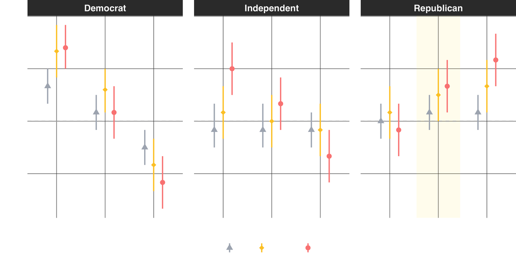

## Application

- The downweighted sample generally leads to bigger treatment effects, but not to smaller confidence intervals
- Crucially, the downweighted sample shows that Republicans click more on the Political piece of news in the Unity condition (original piece failed to reject the null)

## Sensitivity check

- To verify whether the measure actually captures inattentiveness, Ziegler computed marginal effects, using diverse values of $\bar{S_i}$ as cutoff for attentiveness.
- Marginal effects of “Compliers” are generally less noisy, but there seems to be systematic noise across “non-compliers”:

## Sensitivity check

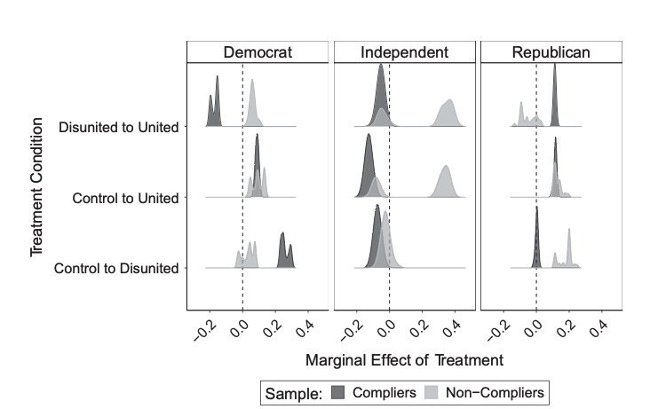

## Critical Assessment

Good step towards a continuous measure of attention

N-grams are tractable and intuitive, do not require external services

Mixture of similarity measures: still rough but potentially interesting to penalize out-of-context writing

## Critical Assessment

**Variance ≠ inattention**

Not all variance across non-compliers can be attributed to inattentiveness.

N-grams do not take into account synonyms, nor context: using synonyms would be penalized, affect-charged writing too.

## Post-treatment bias

- The cosine check is measured **after** treatment exposure.

[figure not shown]

## Post-treatment bias

Ideal usage: “thermometer”, not criterion of exlusion (verification of people that passed/failed an attention check).

Transformer embeddings (context + synonyms) provide better defenses against false negatives.

## Conclusion

Using n-grams and text similarity measures, Ziegler develops a continuous Factual Manipulation Check.

Weighted Least Squares on similarity yield stronger (but not cleaner) treatment effects.

Post-treatment effects cannot be excluded from the results; still an interesting evolution.